# Getting set up with Python

20 Sep 2019

Here are some ways to get started with Python, either online or by installing it on your own computer. The two recommended options are to use the online servers provided or to install `Anaconda` on your own machine.

## CodeLab

### Registration

1. Go to https://codelab4.turingscraft.com/register
2. Follow the directions, including verifying that you’re not a robot and that your email address is valid. **enter your @mcmaster.ca email address, not your personal email address! Your CodeLab grades will not be recorded unless you use your @mcmaster.ca email address**
3. After registering, close all windows, exit the browser, re-open the browser and log in to CodeLab at https://codelab4.turingscraft.com/login
4. Click on the “Add a Course” button in the courses area
5. enter the Section Access Code: **MCMA-27300-LJBG-42** and click `Next>` and confirm.
6. Fill in the Alternate ID field with your MacID (letters+numbers, e.g. `smithj1`) and click `Next>`. **You must correctly enter your macid at this stage.**
7. After clicking on the terms of service agreement you will be able to navigate to the 1MP3 course content.

### Log in

1. Go to https://codelab4.turingscraft.com/login
2. the **username** is the email address given during registration
3. the **password** is the password selected during registration

### Getting full access

1. Log in to CodeLab (if you haven’t already)
2. Click the green `Go` button next to this course
3. Click on the upgrade link shown in a beige band at the top of the window; follow the subsequent directions.
4. Follow the payment directions (options include PayPal/credit card, money order, and payment keys). The cost is US$25.

## Online services

### notebook

The very simplest way to use Python is to go to http://mcmaster.syzygy.ca, log in with your MacID and password, and open a new “Python 3” notebook.

### script + console window

If you want to use a script + console interface (this will be explained in class and tutorial), go to http://mcmaster.syzygy.ca/jupyter/user-redirect/lab, then:

- `File` > `New` > `Text File`
- right-click or shift-click on “untitled.txt” in the left-hand file bar: `Rename` the file to `<myfile>.py` (where `<myfile>` is whatever you want to name your script, e.g. `week1_stuff.py`). (Do **not** include spaces or punctuation other than `_` in your file name.)
- Go to `File` > `New Console for Editor`, open a “Python 3” console
- Rearrange your windows so that you can see the editor window and console at the same time.

### troubleshooting

When accessing the server you might get an error like this:

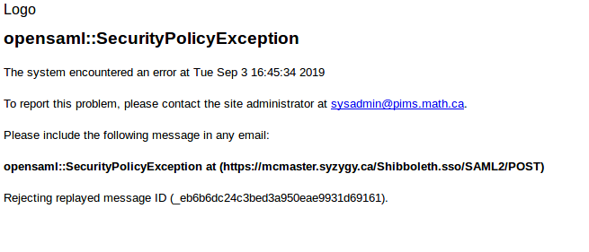

syzygy error

In general it should be OK to ignore it and try again.

## On your own computer (recommended): `Anaconda`

`Anaconda` is a complete Python “stack” (i.e., a set of programs and utilities) that has everything you will need for the class, including `Spyder` (a script + console environment) and a way to run notebooks.

### Installation

- Determine your platform
  - Mac OSX/Linux
    - run `uname -m` in the Terminal (to open a terminal on the Mac, type `Command-Shift-u` to open Utilities; type `t` to select `Terminal`; double-click to open the terminal [or type `Command-Option-o`])
    - `x86_64` means “64-bit”, `i686` means “32-bit” (if you have to guess, it’s likely that you have a 64-bit version)
  - Windows: go [here](http://windows.microsoft.com/en-ca/windows/which-operating-system), follow instructions for your version of Windows
- Install Anaconda with Python 3.7.4 for your platform / architecture from here: http://docs.continuum.io/anaconda/install/ (includes Spyder and a jupyter notebook server)

**note**: During the installation process you can skip the “Install Microsoft VS Code” step.

### Running Spyder

- open the “Anaconda navigator” on your computer and select Spyder (“Launch”)
- or, search for the Spyder executable/application on your computer

### Running notebooks

- open the “Anaconda navigator” on your computer and select jupyter notebook (“Launch”); click on `New > Python3`

If you’re new to computing and not interested in other nuts and bolts, you can stop here!

## Alternative 1: Python 3.7 + text editor

If you’re running Linux or Mac OSX and are comfortable in the terminal, you can get the basic Python 3.7 stack and use your favourite text editor to work with `.py` files.

### Installation

- [Download the Python 3.7.4 installer](https://www.python.org/downloads/)
- Run the installer
- … that’s it
- [Sublime Text 3](http://www.sublimetext.com/3) is a great editor, and has some built-in Python support (syntax highlighting + running scripts).
- [other text editors with Python support](https://wiki.python.org/moin/PythonEditors)

**Note:** the installer will also install the latest version of Python 2, which will be the default if you run it from the terminal using `python`. To avoid this either run python using `python3` or make an alias in your `.bash_profile` from python to the Python 3.7 executable.

## More alternatives: other IDEs

Some [recommended Python IDEs](https://wiki.python.org/moin/IntegratedDevelopmentEnvironments). These all require you to install Python separately, so you will also have to install Anaconda or vanilla Python 3.

### Yet more alternatives

Really you just need some combination of Python stack (Python/Anaconda) and something to edit **plain** text with. Heck, you can even use [`vi`](https://en.wikipedia.org/wiki/Vi) if you’re into that sort of thing. Do **not** use a regular WYSIWYG text editor like MS Word: you will be opening yourself up to a world of pain.

## Miscellaneous

### Python version checking

```
python -c "import sys; print(sys.version)"
```

directly from Terminal.

### Package installation

Anaconda should come with all the packages you will need for this course. To install a Python package on Linux/OSX you can use `pip3` (for Python 3.7) as follows:

```
pip3 install "numpy"
```

for example, to install the [`numpy`](http://www.numpy.org/) package. Replace `numpy` with whatever package you need.